# Does a Sports Team’s Performance Affect Its City’s Murder Rate?

```r
suppressPackageStartupMessages({
  library(tidyverse)
  library(glmnet)     # LASSO variable selection
  library(sandwich)   # cluster-robust covariance
  library(lmtest)     # coeftest() with a supplied vcov
  library(broom)
})

set.seed(123)
options(scipen = 999, digits = 4)
```

## Approach

The question is whether a team **performing better** moves its city’s murder rate – a within-team, over-time question. Rather than four separate league models, this fits **one pooled model** on a *stacked* panel: one row per **(city, year, team)**, with every league’s team stacked together. That keeps all the data in a single regression while avoiding the traps of the original design (forcing every league onto one metro-year row and median-imputing the missing sports values).

Key pieces:

- **Outcome:** each team’s own city murder rate, paired with its own performance – never averaged across leagues, never imputed.
- **`win_pct` standardized within league** (z-score), so one pooled coefficient means “effect of a 1-SD-better season” and is comparable across sports whose win percentages have very different spreads (an NFL season swings far more than a 162-game MLB season).
- **Team fixed effects** (`factor(team_id)`, one intercept per city-league team): the win-% effect is identified purely from a team’s year-to-year swings, so stable differences between teams/cities (big cities have teams *and* more crime) cannot drive it.
- **Year fixed effects** for nationwide crime trends, and **SEs clustered by metro** since a metro’s rows (across years and leagues) are correlated.

A pooled model *without* team fixed effects (league intercepts only) is shown alongside, so the confounding the fixed effects remove is visible.

```r
raw <- read_csv("data/metro_acs_model_ready_2010_2023.csv", show_col_types = FALSE) %>%
  mutate(across(c(year, GEOID), as.integer))

# Time-varying census controls (metro-level). Fixed effects absorb everything
# time-invariant, and each concept appears once (rates, not the raw counts they
# are built from) to avoid the rank-deficiency the earlier all-columns model hit.
controls <- c("log_income", "unemployment_rate", "poverty_rate",
              "log_home_value", "log_pop",
              "race_black_nonhispanic_rate", "hispanic_or_latino_rate",
              "bachelors_plus_rate", "pop_18_to_64_rate")

base <- raw %>%
  mutate(
    log_income     = log(median_household_income),
    log_home_value = log(median_home_value),
    log_pop        = log(total_population)
  )
```

```r
leagues <- c("nfl", "mlb", "nhl", "cfb")

# Stack every league into one long panel: one row per (metro, year, team) that
# actually exists. Each league contributes its own murder rate + performance.
long <- map_dfr(leagues, function(lg) {
  base %>%
    transmute(
      GEOID, year, league = toupper(lg),
      murder_rate        = .data[[paste0(lg, "_murder_rate")]],
      win_pct            = .data[[paste0(lg, "_win_pct")]],
      make_playoffs      = .data[[paste0(lg, "_make_playoffs")]],
      make_playoffs_prev = .data[[paste0(lg, "_make_playoffs_prev")]],
      across(all_of(controls))
    ) %>%
    filter(!is.na(murder_rate), !is.na(win_pct))
}) %>%
  # standardize win % WITHIN league so a pooled coefficient = effect of a
  # 1-SD-better season, comparable across sports
  group_by(league) %>%
  mutate(win_pct_z = as.numeric(scale(win_pct))) %>%
  ungroup() %>%
  # lagged (previous-season) standardized win %, within each team
  mutate(team_id = paste(GEOID, league, sep = "_")) %>%
  group_by(team_id) %>%
  arrange(year, .by_group = TRUE) %>%
  mutate(win_pct_prev_z = lag(win_pct_z)) %>%
  ungroup() %>%
  # drop NA on every model variable so the fitted rows match the cluster vector
  drop_na(all_of(c("win_pct_z", "win_pct_prev_z", "make_playoffs",
                   "make_playoffs_prev", "murder_rate", controls)))

tibble(
  observations = nrow(long),
  teams = n_distinct(long$team_id),
  metros = n_distinct(long$GEOID),
  years = n_distinct(long$year)
)
```

```
## # A tibble: 1 × 4
##   observations teams metros years
##          <int> <int>  <int> <int>
## 1         1298   123     72    11
```

```r
count(long, league)
```

```
## # A tibble: 4 × 2
##   league     n
##   <chr>  <int>
## 1 CFB      582
## 2 MLB      220
## 3 NFL      289
## 4 NHL      207
```

```r
sports_terms <- c("win_pct_z", "win_pct_prev_z", "make_playoffs", "make_playoffs_prev")

rhs <- paste(c("win_pct_z", "win_pct_prev_z", "make_playoffs",
               "make_playoffs_prev", controls, "factor(year)"),
             collapse = " + ")

# pooled, league intercepts only (no team fixed effects)
fit_naive <- lm(as.formula(paste("murder_rate ~", rhs, "+ factor(league)")), data = long)
# one big model WITH team fixed effects
fit_fe    <- lm(as.formula(paste("murder_rate ~", rhs, "+ factor(team_id)")), data = long)

# metro-clustered coefficients for the sports terms
clustered <- function(fit) {
  V <- sandwich::vcovCL(fit, cluster = long$GEOID, type = "HC1")
  broom::tidy(lmtest::coeftest(fit, vcov. = V)) %>%
    filter(term %in% sports_terms)
}
```

## Variable selection: LASSO (fixed effects forced in)

Before trusting the regression, LASSO is run over **every** predictor – the sports terms and the census controls – to see which survive penalization. The team and year fixed effects are included in the same design matrix but **forced in unpenalized** (`penalty.factor = 0`), so LASSO can never drop a fixed effect; it only chooses among the substantive variables *on top of* the fixed effects. If the sports terms carry real signal, they should survive; if they are noise, LASSO should shrink them away.

```r
lasso_form <- as.formula(
  paste("~", paste(c(sports_terms, controls, "factor(year)", "factor(team_id)"),
                   collapse = " + ")))
X <- model.matrix(lasso_form, data = long)[, -1]
y <- long$murder_rate

# 0 = forced in (the fixed-effect dummies), 1 = penalized/selectable (everything else)
is_fe <- grepl("^factor\\(year\\)|^factor\\(team_id\\)", colnames(X))
penalty <- ifelse(is_fe, 0, 1)
cat(ncol(X), "columns |", sum(is_fe), "fixed-effect dummies forced in |",
    sum(!is_fe), "penalized (sports + census)\n")
```

```
## 145 columns | 132 fixed-effect dummies forced in | 13 penalized (sports + census)
```

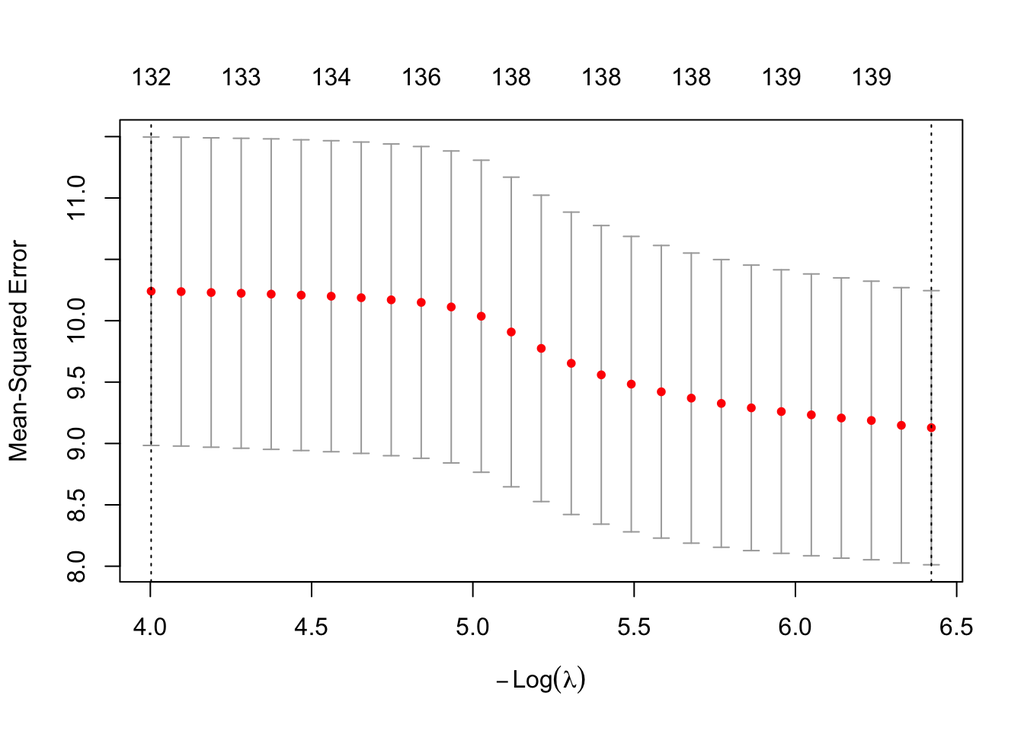

```r
set.seed(123)
cv_lasso <- cv.glmnet(X, y, alpha = 1, penalty.factor = penalty, nfolds = 10)
plot(cv_lasso)
```

```r
# substantive (non-fixed-effect) variables LASSO keeps at each lambda
kept <- function(s) {
  co <- coef(cv_lasso, s = s)[, 1]
  co <- co[co != 0 & !grepl("^factor\\(|Intercept", names(co))]
  tibble(variable = names(co), coefficient = round(co, 4))
}
```

```r
cat("--- kept at lambda.min (looser) ---\n"); print(kept("lambda.min"))
```

```
## --- kept at lambda.min (looser) ---
```

```
## # A tibble: 7 × 2
##   variable          coefficient
##   <chr>                   <dbl>
## 1 win_pct_z             -0.120
## 2 win_pct_prev_z        -0.187
## 3 make_playoffs         -0.0146
## 4 log_income            -4.16
## 5 unemployment_rate     -1.08
## 6 poverty_rate           0.738
## 7 log_home_value        -5.97
```

```r
cat("\n--- kept at lambda.1se (parsimonious) ---\n")
```

```
##
## --- kept at lambda.1se (parsimonious) ---
```

```r
k1 <- kept("lambda.1se")
if (nrow(k1) == 0) cat("(none -- only the fixed effects survive)\n") else print(k1)
```

```
## (none -- only the fixed effects survive)
```

At the parsimonious `lambda.1se`, **no** sports or census variable survives – the team and year fixed effects alone explain the murder rate, and nothing else earns its place. At the looser `lambda.min` a few variables enter, but the sports coefficients are tiny. Either way LASSO is telling the same story the regression does: performance adds essentially nothing beyond who the team is and what year it is.

## Post-LASSO regression

The regression is then refit on the LASSO-selected variables (`lambda.min`) plus the forced-in fixed effects, and the sports terms among the survivors are reported with metro-clustered SEs – so any performance effect that cleared selection still faces honest inference.

```r
selected <- kept("lambda.min")$variable
selected_sports <- intersect(selected, sports_terms)
selected_ctrls  <- intersect(selected, controls)

post_rhs <- paste(c(selected_sports, selected_ctrls,
                    "factor(year)", "factor(team_id)"), collapse = " + ")
post_fit <- lm(as.formula(paste("murder_rate ~", post_rhs)), data = long)

V <- sandwich::vcovCL(post_fit, cluster = long$GEOID, type = "HC1")
broom::tidy(lmtest::coeftest(post_fit, vcov. = V)) %>%
  filter(term %in% sports_terms) %>%
  mutate(across(where(is.numeric), ~round(.x, 4)))
```

```
## # A tibble: 3 × 5
##   term           estimate std.error statistic p.value
##   <chr>             <dbl>     <dbl>     <dbl>   <dbl>
## 1 win_pct_z       -0.154      0.124   -1.24    0.216
## 2 win_pct_prev_z  -0.208      0.122   -1.70    0.0895
## 3 make_playoffs    0.0025     0.343    0.0074  0.994
```

## The one big model: sports effects (naive vs. team fixed effects)

`win_pct_z` is the effect of a **1-SD-better season** on murders per 100k; the playoff terms are indicators. The naive column pools with league intercepts only; the FE column adds a fixed effect for every team, with SEs clustered by metro.

```r
nv <- clustered(fit_naive) %>% select(term, naive_coef = estimate, naive_p = p.value)
fe <- clustered(fit_fe) %>%
  select(term, fe_coef = estimate, fe_cluster_se = std.error, fe_p = p.value)

left_join(nv, fe, by = "term") %>%
  mutate(term = factor(term, levels = sports_terms)) %>%
  arrange(term) %>%
  mutate(across(where(is.numeric), ~round(.x, 4)))
```

```
## # A tibble: 4 × 6
##   term               naive_coef naive_p fe_coef fe_cluster_se   fe_p
##   <fct>                   <dbl>   <dbl>   <dbl>         <dbl>  <dbl>
## 1 win_pct_z              -0.260  0.308   -0.141         0.123 0.251
## 2 win_pct_prev_z         -0.426  0.244   -0.208         0.114 0.0696
## 3 make_playoffs          -1.40   0.0554  -0.085         0.214 0.691
## 4 make_playoffs_prev      2.46   0.0968   0.242         0.301 0.422
```

## Model fit

```r
tibble(
  model = c("naive (league intercepts)", "team fixed effects"),
  n = nrow(long),
  # R^2 is dominated by the team dummies in the FE model (each team has its own
  # intercept), so a high value mostly reflects that murder rates differ across
  # cities, not covariate predictive power.
  r_squared = c(summary(fit_naive)$r.squared, summary(fit_fe)$r.squared),
  adj_r_squared = c(summary(fit_naive)$adj.r.squared, summary(fit_fe)$adj.r.squared)
)
```

```
## # A tibble: 2 × 4
##   model                         n r_squared adj_r_squared
##   <chr>                     <int>     <dbl>         <dbl>
## 1 naive (league intercepts)  1298     0.543         0.533
## 2 team fixed effects         1298     0.964         0.959
```

## Reading the results

- The **FE column is the credible one.** If `win_pct_z` there is small relative to its clustered SE (|coef| under ~2 SE), the honest conclusion is **no detectable within-team effect** of performance on murder – a legitimate, defensible finding.
- Compare **naive vs. FE**: where the naive coefficient is larger or “significant” and the FE one is not, that gap is the confounding the team fixed effects strip out (team-having cities differ in ways unrelated to how the team plays). This is exactly why the original pooled all-columns model could not answer the question.
- **Caveats:** clusters are a few dozen metros, so clustered SEs are approximate – a wild-cluster bootstrap would be the rigorous next step. Fixed effects also absorb slow-moving controls, so the census coefficients are not the focus; the sports terms are. Four performance measures are tested, so treat any single borderline p-value with multiple-comparisons skepticism. ```